# GLMMs for the Microbiome: Code Tutorial

Amy Sweeny

01/10/2022

# Applying GLMMs to wild metabarcoding data

This is a tutorial illustrating the methods presented in Sweeny et al. 2020 (https://www.biorxiv.org/content/10.1101/2020.11.24.395715v2.full)

We provide an outline of applying generalised linear mixed-effects models to relative abundance tables of metabarcoding data as a means to account for complex covariates that are present in wildlife microbiota datasets. The below from the preprint illustrates the model formulation and output.

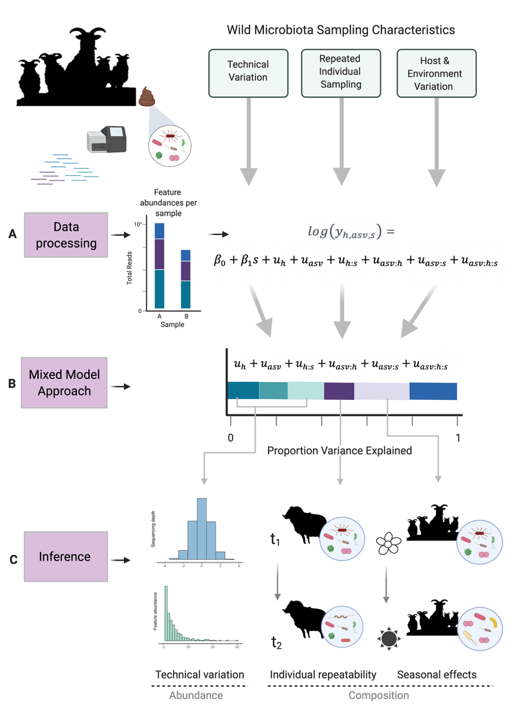

For computing efficiency, an anonymised subset of one of the pilot datasets used in the companion manuscript is used in this tutorial and can be downloaded in the ‘Data’ folder on github.

# 0. Set-up

## To run this tutorial you will require the following packages:

```r
library(tidyverse) # data manipulation and ggplot
library(janitor) # data cleaning
library(magrittr)  # data manipulation
library(reshape2) # data manipulation
library(phyloseq) # output format of sequence processing
library(microbiome) # useful exploration and visualisation functions
library(MCMCglmm) # implementation of GLMMs
library(ALDEx2) # CLR transformations
library(plotrix) # std error functions
library(pals) # palettes
library(MetBrewer) # palettes
library(ggregplot) # package my friend made with lots of handy funcions - https://github.com/gfalbery/ggregplot
```

## Plot admin

Set-up some palettes for later use

```r
MicroColours <- met.brewer("Renoir",12, "discrete")
MicroColoursRamp <- colorRampPalette(MicroColours)
MicroColoursExpand <- MicroColoursRamp(n=20)
MicroColoursCat <- list(
  Age = MicroColours[c(3,4)],
  Sex= MicroColours[c(1,5)],
  Season=MicroColours[c(2,8)]
) #%>% unlist()


AmyTheme <- theme_bw(base_size=14) +
  theme(
    axis.title = element_text(colour="black"),
    axis.title.x = element_text(angle=45, hjust=1)
  )
```

## Reading in data objects

We will use the phyloseq object representing the feature abundance table, metadata, and taxonomy table for exploration of the data and analysis presented in the first section of the results (alpha and beta diversity).

We will use the csv object representing the phyloseq objected ‘melted’ into one dataframe for the mixed modelling approach outlined in Section 3.1

```r
path <- "Data/"
df <- read_csv(paste0(path, "GLMMMTutorialData.csv")) # csv file
ps <- readRDS(paste0(path,"PhyloseqGLMM.rds")) # phyloseq object
```

## Explore the dataset

### Summarise phyloseq object

This data was previously filtered for a total abundance of 250 reads, so we have no singletons and a total of 794 ASVs and 30 samples we will proceed with.

```r
ps
```

```
## phyloseq-class experiment-level object
## otu_table()   OTU Table:         [ 794 taxa and 30 samples ]
## sample_data() Sample Data:       [ 30 samples by 3 sample variables ]
## tax_table()   Taxonomy Table:    [ 794 taxa by 6 taxonomic ranks ]
```

```r
summarize_phyloseq(ps)
```

```
## [[1]]
## [1] "1] Min. number of reads = 20375"
##
## [[2]]
## [1] "2] Max. number of reads = 46860"
##
## [[3]]
## [1] "3] Total number of reads = 1093264"
##
## [[4]]
## [1] "4] Average number of reads = 36442.1333333333"
##
## [[5]]
## [1] "5] Median number of reads = 36980.5"
##
## [[6]]
## [1] "7] Sparsity = 0.606591099916037"
##
## [[7]]
## [1] "6] Any OTU sum to 1 or less? NO"
##
## [[8]]
## [1] "8] Number of singletons = 0"
##
## [[9]]
## [1] "9] Percent of OTUs that are singletons \n        (i.e. exactly one read detected across all samples)0"
##
## [[10]]
## [1] "10] Number of sample variables are: 3"
##
## [[11]]
## [1] "age_class" "sex"       "side"
```

### A look at the metadata

Sample variables include a mix of age classes (15 lamb and 15 adult), males and females, and individuals from the east and west side of the study system. Samples are row names.

```r
sample_data(ps) %>% as.data.frame() %>%  head
```

```
##     age_class    sex side
## S57     Adult Female East
## S61      Lamb Female West
## S48      Lamb   Male West
## S42     Adult Female East
## S50      Lamb Female East
## S34      Lamb Female West
```

## Relative abundance and alpha and beta diversity analysis

### Community composition summary

By far community dominated by Firmicutes and Bacteroidetes

```r
psPhy <- tax_glom(ps, taxrank = "phylum") # aggregates to the phylum level
psMelt <- psmelt(psPhy) # melts into a combined df for plots

SampleDepth <- psMelt %>%
  group_by(Sample) %>%
  summarise(Depth=sum(Abundance)) %>% as.data.frame() # summarise reads per sample
RelAbundance <- full_join(psMelt, SampleDepth) %>%
  group_by(Sample, phylum) %>%
  summarise(RelAbundance=Abundance/Depth) %>% as.data.frame() # summarise proportion of each phyla for each sample

require(plotrix)
RelAbundanceMean <- RelAbundance %>%
  dplyr::select(-Sample) %>%  group_by(phylum) %>%
  summarise_each(funs(mean, sd, std.error)) %>%
  arrange(desc(mean)) # summarise proportion of phyla across all samples

RelAbundanceMean
```

```
## # A tibble: 16 × 4
##    phylum                 mean       sd std.error
##    <chr>                 <dbl>    <dbl>     <dbl>
##  1 Firmicutes         0.471    0.0940    0.0172
##  2 Bacteroidetes      0.380    0.0993    0.0181
##  3 Proteobacteria     0.0546   0.112     0.0204
##  4 Fibrobacteres      0.0320   0.0234    0.00427
##  5 Verrucomicrobia    0.0175   0.0366    0.00667
##  6 Cyanobacteria      0.0153   0.0116    0.00213
##  7 Spirochaetes       0.00853  0.00665   0.00121
##  8 Epsilonbacteraeota 0.00639  0.0122    0.00223
##  9 Tenericutes        0.00464  0.00292   0.000533
## 10 Lentisphaerae      0.00241  0.00207   0.000378
## 11 Euryarchaeota      0.00220  0.00334   0.000610
## 12 Kiritimatiellaeota 0.00173  0.00205   0.000375
## 13 Planctomycetes     0.00147  0.00120   0.000219
## 14 Actinobacteria     0.00139  0.00276   0.000504
## 15 Fusobacteria       0.000475 0.00260   0.000475
## 16 Elusimicrobia      0.000396 0.000949  0.000173
```

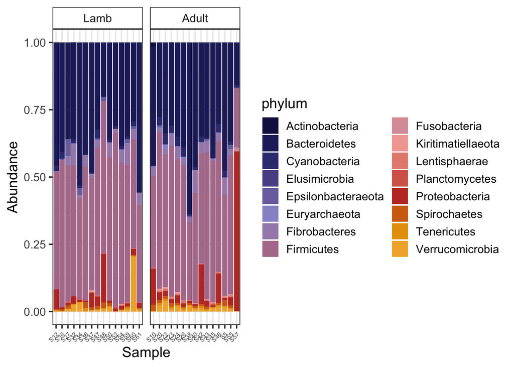

```r
ggplot(psMelt, aes(x = Sample, y = Abundance, fill = phylum)) +
  geom_bar(stat = "identity", position = "fill", colour="transparent") +
  scale_fill_manual(values=MicroColoursExpand) +
  facet_grid(~age_class, scales="free_x") +
  theme_bw(base_size = 14) + # labs(subtitle = "B") +
  guides(fill=guide_legend(ncol=2)) +
  theme(axis.text.x = element_text(angle=45, hjust=1, size=6),
        strip.background = element_rect(fill="white"))
```

# 1. Alpha & Beta Diversity Community Analysis

### Alpha diversity

Significant differences in diversity between age classes

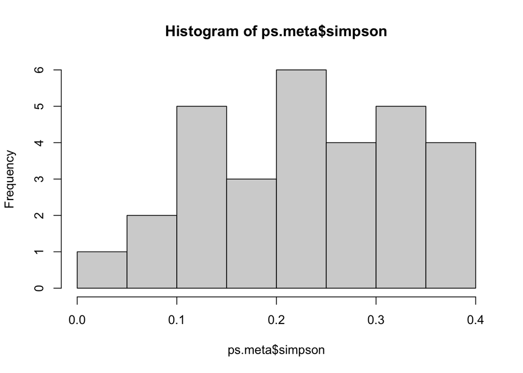

```r
# alpha metrics
ps.even <- evenness(ps, index = "all")

ps.meta <- meta(ps)
ps.meta$simpson <- ps.even$simpson
hist(ps.meta$simpson)
```

```r
# test for normality
shapiro.test(ps.meta$simpson) # p=0.3525 - data not violating normality
```

```
##
##  Shapiro-Wilk normality test
##
## data:  ps.meta$simpson
## W = 0.96222, p-value = 0.3525
```

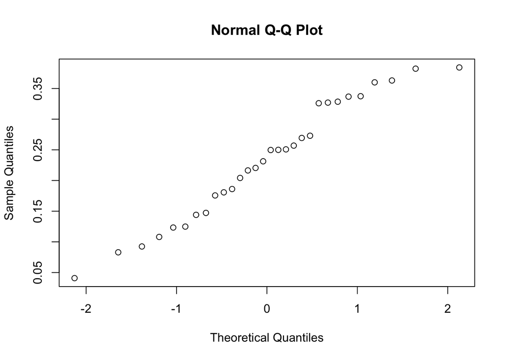

```r
qqnorm(ps.meta$simpson) # looks okay
```

```r
# compare between host groups
SimpsonTestAge<- t.test(ps.meta$simpson[ps.meta$age_class=="Lamb"], ps.meta$simpson[ps.meta$age_class=="Adult"])

SimpsonTestAge # p = 0.0197
```

```
##
##  Welch Two Sample t-test
##
## data:  ps.meta$simpson[ps.meta$age_class == "Lamb"] and ps.meta$simpson[ps.meta$age_class == "Adult"]
## t = -2.4932, df = 24.811, p-value = 0.0197
## alternative hypothesis: true difference in means is not equal to 0
## 95 percent confidence interval:
##  -0.14879071 -0.01414539
## sample estimates:
## mean of x mean of y
## 0.1917007 0.2731688
```

#### Visualise alpha diversity differences between age classes

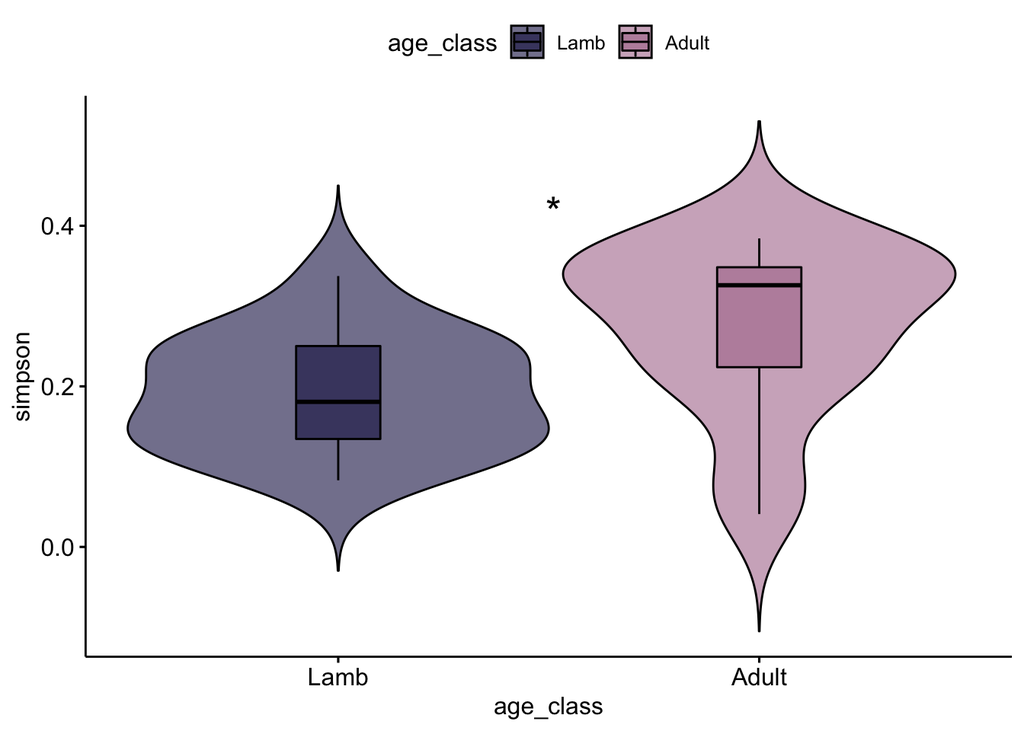

```r
require(ggpubr)
alpha.ps <- ps.meta %>%
  ggviolin(., x="age_class", y="simpson",
                add = "boxplot", fill = "age_class",
                palette = c(MicroColoursCat$Sex),
                alpha=0.6, add.params = list(alpha=0.6),
                legend = "top") +
  stat_compare_means(method = "t.test",
                     aes(label=..p.signif..),
                     label.x=1.5, label.y=0.4,
                     size=7)

alpha.ps
```

### Beta diversiy

```r
ps.rel <- microbiome::transform(ps, "compositional")
bx.ord_pcoa_bray <- ordinate(ps.rel, "PCoA", "bray")

metadf.bx <- data.frame(sample_data(ps.rel))
bray_ps.bxn <- phyloseq::distance(physeq = ps.rel, method = "bray")

set.seed(999)
# Adonis test
library(vegan)
adonis.test <- adonis(bray_ps.bxn ~ age_class, data = metadf.bx)
adonis.test<-clean_names(adonis.test$aov.tab)
```

PERMANOVA results

|  | df | sums_of_sqs | mean_sqs | f_model | r2 | pr_f |
| --- | --- | --- | --- | --- | --- | --- |
| age_class | 1 | 0.7568348 | 0.7568348 | 4.145245 | 0.1289536 | 0.001 |
| Residuals | 28 | 5.1122134 | 0.1825791 | NA | 0.8710464 | NA |
| Total | 29 | 5.8690482 | NA | NA | 1.0000000 | NA |

#### Visualise composition differences between host groups

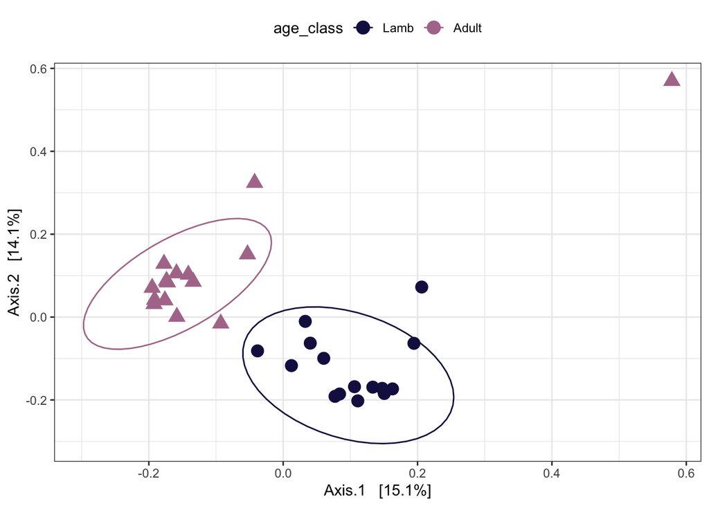

```r
beta.ps <- plot_ordination(ps.rel,
                             bx.ord_pcoa_bray,
                             color="age_class"
                             #label = "sample_id",
) +
  geom_point(aes(shape = age_class), size= 4) +
  scale_colour_manual(values=MicroColoursCat$Sex)+
  theme_bw() +
  theme(plot.title = element_text(hjust = 0, size = 12),
        legend.position = "top")+
  stat_ellipse()+
  guides(shape="none")


beta.ps
```

# 2. Mixed Model Analysis

Mixed models here will all be carried out in MCMCglmm, but your favourite package/ program should work just fine with some adaptation as well. Feel free to contact me about syntax switches between algorithms.

## 2A. Poisson GLMMs

- These models produce the main results of the manuscript and use the raw read count per ASV per sample as the response with Poisson error families
- Below we also present alternative approaches for computing speed and adjustment of questions asked by the model

### Model set-up

- read abundance as response
- fixed effects should be relevant host factors that may affect sample variation in read abundance - in this instance samples were collected from adults and lambs to examine effects of age on the gut microbiome

```r
Mods <- list()

mf <- 20 # multiplier for model iterations and chains
resp<-"abundance"
fixed<- c("age_class")

mcmcF<- as.formula(paste(resp, "~", paste(fixed)))

Prior3 <- list(R = list(V = diag(1), nu = 0.002),
               G = list(G1 = list(V = diag(1), nu = 0.002, alpha.mu = rep(0,1), alpha.V = diag(1)*100),
                        G2 = list(V = diag(1), nu = 0.002, alpha.mu = rep(0,1), alpha.V = diag(1)*100),
                        G3 = list(V = diag(1), nu = 0.002, alpha.mu = rep(0,1), alpha.V = diag(1)*100)))
```

You can run the model below, or read in the model object which was run from the code!

```r
# to run the model
Mods[[1]]<- MCMCglmm(fixed= mcmcF,
                          random= ~  sample + asv + age_class:asv,
                          prior=Prior3,
                          data=df,
                          verbose=T, pr=T, pl=T, # will save posteriors for random effect levels & model predictions for each iteration
                          family = "poisson",
                          nitt = 13000*mf,
                          thin = 10*mf,burnin=3000*mf)
```

Notes: * verbose = T will print progress * pr = T saves posterior distributions for all random effect levels (see section 4) * pl = T saves latent variables (model predicted variables for every data point & iteration, useful for testing for excess zeroes) * Note this did take my laptop ~ 90 minutes to run, so not a fast model!

Read in the model object here if you didn’t run the above

```r
Mods[[1]] <- readRDS("Output/PoissonModel.rds")
```

View proportion variance associated with each random term

```r
PropVarPois <- MCMCRep(Mods[[1]], scale="link") %>% # function from ggregplot to calculate proportion variance for each random effect
  as.data.frame() %>%
  mutate_at(c("Mode", "lHPD", "uHPD"), as.numeric)

PropVarPois
```

```
##       Component       Mode        lHPD       uHPD
## 1        sample 0.01203397 0.007792082 0.02416657
## 2           asv 0.17223235 0.146959862 0.21102106
## 3 age_class:asv 0.21607760 0.193830355 0.24683450
## 4         units 0.53964912 0.518421149 0.55962454
```

Variance components often will not add to 1 because there is some variance attributable to the poisson process. We’ll calculate that and visualise the variance breakdown for this model.

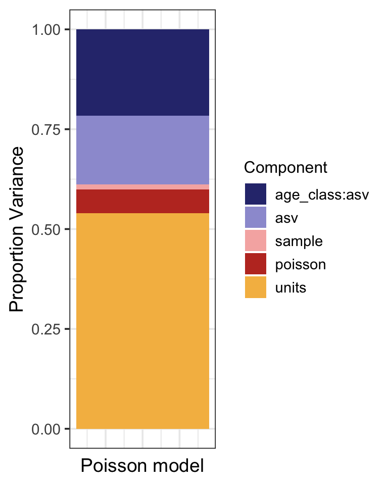

```r
PropVarPois %>% pull(Mode) %>% sum -> TotalVar
1- TotalVar -> PoissonVar

PropVarPois[5, ] <- c("poisson", PoissonVar, NA, NA)

PropVarPois%>%
  mutate(Component=fct_relevel(Component, "age_class:asv", "asv", "sample","poisson", "units")) %>%
  ggplot(aes(x=1, y=as.numeric(Mode), fill=Component)) +
  geom_bar(stat="identity", colour="transparent") +
  scale_x_continuous(labels=NULL) +
  scale_fill_manual(values=MicroColours[c(2,4,6,8,10)]) +
  theme_bw(base_size = 14) +
  #theme(legend.position = "top") +
  theme(axis.ticks.x = element_blank(),
        legend.text = element_text(size=11),
        legend.title = element_text(size=12)) +
  labs(x='Poisson model', y='Proportion Variance')
```

# 3. Differential abunance analysis

## Rank taxa effects

Let’s pull out the posterior distributions relevant to our host age groups of interest

```r
Solutions<-Mods[[1]]$Sol[, 1:dim(Mods[[1]]$Z)[2]]

SolutionsDF<- Solutions %>% as.data.frame()

SolKeepAge <- SolutionsDF %>% dplyr::select(contains("age_class:asv")) %>% colnames()

SolutionsAge<- SolutionsDF %>% dplyr::select(SolKeepAge)

SolutionsAdult <- SolutionsAge %>%
  gather(key="level", value="posterior") %>% as.data.frame() %>%
  separate(level, into=c("term", "age_class", "asv"), sep="[.]")
```

```r
RanefPostComp<- function(df, comps, taxa, var){
  require(tidyverse)
  require(MCMCglmm)
  not_all_na <- function(x) any(!is.na(x))
  df$group <- df[, var]
  df$taxa <- df[, taxa]
  df<- df %>% filter(term!="(Intercept)") %>%
    mutate(taxa=as.factor(taxa))
  LevelComps<-list()
  Levels=levels(df[, "taxa"])
  for(x in 1:length(Levels)){
    post1 <- df %>% subset(taxa==Levels[x] & group== comps[1]) %>% pull(posterior)
    post2 <- df %>% subset(taxa==Levels[x] & group== comps[2]) %>% pull(posterior)
    if(length(post2>0 ) & length(post1>0)){
      postComp <- post2-post1 %>% as.matrix()
    }
    else{
      postComp <- rep(NA, 1000)
    }
    LevelComps[[x]] <-postComp
  }
  LevelCompsFin<- bind_cols(LevelComps) %>% as.matrix()
  colnames(LevelCompsFin) <- paste(Levels, comps[[2]], sep=".")
  LevelCompsFin %>% as.data.frame() %>% select_if(not_all_na) -> df

  df1<-apply(df,2, function(a) mean(a)[1])
  df1l<-apply(df,2,function(a)  HPDinterval(as.mcmc(a))[1])
  df1u<-apply(df,2,function(a)  HPDinterval(as.mcmc(a))[2])
  df1v<-apply(df,2,function(a)  var(a)[1])

  df2 <- cbind(df1, df1l, df1u, df1v)
  colnames(df2) <- c("mean", "lower", "upper", "var")
  df2 <- df2 %>% as.data.frame() %>%
    rownames_to_column(var="term") %>%
    mutate(taxa=sapply(str_split(term, "[[.]]"), '[', 1),
           effect=var,
           nonZeroCI= ifelse(lower<0&upper<0, "Y",
                       ifelse(lower>0&upper>0, "Y", "N")))
  colnames(df2)[which(names(df2) == "taxa")] <- paste(taxa)
  return(df2)

}
```

Let’s apply this function to the age-related posterior distributions from the model. This will take a little while to run, especially for datasets larger than this test data! (Or just read them in below)

```r
ASVByAge <- RanefPostComp(SolutionsAdult,
                          comps=c("Lamb", "Adult"),
                          taxa="asv",
                          var="age_class")

rm(var) # to avoid conflict later with another function
```

Or read in here:

```r
ASVByAge <- read_csv("Output/ASVbyAge.csv")
```

## Visualise taxa effects

Let’s prep the taxonomy rank effects for visualisation with some extra information

```r
Taxo <- df %>% filter(!duplicated(asv)) %>%
  dplyr::select(asv, phylum, fam) %>% as.data.frame() %>%
  rename(family=fam) # MCMCglmm get's a little cranky if a variable in the df is called family so was renamed previously

Prev <- df %>% group_by(asv) %>%
  summarise(prevASV=length(abundance[abundance>0])/ 30) %>%  # n samples
  arrange(-prevASV)

TaxoDf <- left_join(Prev, Taxo)

TaxAge <- merge(ASVByAge, TaxoDf, by="asv", all.x=TRUE)
```

Identify taxa with the strongest effects (positive & negative shifts)

```r
TaxAge %>% group_by(phylum) %>% na.omit() %>%
  summarise(nASV=length(asv)) %>% filter(nASV>1) %>%
  pull(phylum) %>% as.character() -> keepPhy # retain Phylum with > 1 asv for visualisation

TopAgeASV<- TaxAge %>%
  filter(nonZeroCI=="Y") # pull out taxa effects with CI not spanning zero

Top50 <- TaxAge %>% arrange(-mean) %>%
  filter(phylum %in% keepPhy) %>%
  dplyr::select(asv, phylum, lower, upper, mean) %>%
  #filter(lower>0) %>%  #make sure errors don't span zero
  top_n(50) %>%
  mutate(group="real")

Bottom50 <- TaxAge %>% arrange(-mean) %>%
  filter(phylum %in% keepPhy) %>%
  dplyr::select(asv, phylum, lower, upper, mean) %>%
  #filter(upper<0.1) %>%
  top_n(-50) %>%
  mutate(group="real")
```

Create some filler categories for the axis breaks for creating a panel with highest ranked taxa (see Fig 2B & 2D)

```r
DummiesAge<-paste0("dummy", rep(1:25))
GroupAge<-rep("dummy", 25)

DummyAge<- cbind(DummiesAge, GroupAge) %>% as.data.frame()
colnames(DummyAge)<- c("asv", "group")

select50<- bind_rows(Top50, DummyAge, Bottom50)
select_x_age<- select50 %>% pull(asv)
```

```r
MicroColoursPhy <- MicroColours
PlotPal <- data.frame(keepPhy, MicroColoursPhy[c(1,3,4:10,12)])
colnames(PlotPal) <- c("phylum", "colour")

AgeTopBottom<-
  select50 %>% filter(!is.na(phylum)) %>%
  ggplot(aes(x=reorder(asv, mean), y=mean, colour=phylum))+
  geom_point(position=position_dodge(w=0.4), size=1.5)+
  geom_errorbar(position=position_dodge(w=0.5),
                aes(ymin=lower,ymax=upper),size=0.3,width=0.2)+
  geom_segment(aes(y=0, yend=0, x=120, xend=70), colour="black", size=0.7)+
  geom_segment(aes(y=0, yend=0, x=70, xend=50), linetype="dashed", colour="black", size=0.7)+
  geom_segment(aes(y=0, yend=0, x=50, xend=0), colour="black", size=0.7)+
  #geom_hline(aes(yintercept=0, linetype=group))+
  theme_classic(base_size = 14)+labs(x=NULL)+
  scale_colour_manual(values=PlotPal %>%
                        filter(phylum %in% select50$phylum) %>%
                        mutate(colour=as.character(colour)) %>%
                        pull(colour),
                      breaks=unique(as.character(select50$phylum)) %>%
                        sort()) +
  scale_x_discrete(limits=rev(select_x_age))+
  #geom_vline(aes(xintercept=50.5, colour="grey"), size=0.2) +
  coord_flip()+
  theme(strip.text.x = element_text(size = 0.8),
        strip.background =element_rect(fill="white"),
        axis.text.y = element_blank(),
        axis.ticks.y=element_blank())+
  labs(subtitle = "B")

TaxAge  %>% na.omit() %>% subset(phylum %in% keepPhy) -> SinaDFAge

AgeSina<-
  ggplot() +
  geom_violin(data=SinaDFAge,
              aes(y=mean, x=phylum, fill=phylum),
              colour="transparent", alpha=0.2) +
  ggforce::geom_sina(data=SinaDFAge,aes(y=mean, x=phylum, size=1/var, colour=phylum), alpha=0.3) +
  scale_size(range=c(0.15, 3), name="Inverse Variance") +
  scale_colour_manual(values=PlotPal %>%
                        filter(phylum %in% SinaDFAge$phylum) %>%
                        mutate(colour=as.character(colour)) %>%
                        pull(colour),
                      breaks=unique(as.character(SinaDFAge$phylum)) %>%
                        sort()) +
  scale_fill_manual(values=PlotPal %>%
                        filter(phylum %in% SinaDFAge$phylum) %>%
                        mutate(colour=as.character(colour)) %>%
                        pull(colour),
                      breaks=unique(as.character(SinaDFAge$phylum)) %>%
                        sort()) +
  geom_hline(yintercept=0, linetype="dashed")+
  theme_bw(base_size = 14) +
  #coord_flip() +theme_ipsum(base_size = 10) +
  theme(axis.text.x = element_text(angle=45, hjust=1),
        axis.title.x = element_blank(),
        legend.position = "top")+ #+facet_wrap(~phylum) +
  guides(colour=FALSE, fill=FALSE)

AgeSinaRect <- AgeSina+
  geom_rect(data=Top50,
            aes(xmin=0.75, xmax=10.25, ymin=min(mean-0.15), ymax=max(mean+0.25)),
            fill="transparent", color="grey60",size=0.5) +
  geom_rect(data=Bottom50,
            aes(xmin=0.75, xmax=10.25, ymin=min(mean-0.30), ymax=max(mean+0.25)),
            fill="transparent", color="grey60",size=0.5)+
  labs(subtitle = "A")
```

We can now visualise a plot comparable (but with fewer ASVs) to Figure 2 in the manuscript, where the highest ranked positive and negative shifts are highlighted by the rectangle in panel A & panel B forest plot.

As in the manuscript, although there is a lot of variation within phlya, the majority of highly positive shifts (increases into adulthood) are found in the Bacteroidetes, and the majority of the highly negative shifts (decreases into adulthood) are found in the Firmicutes.

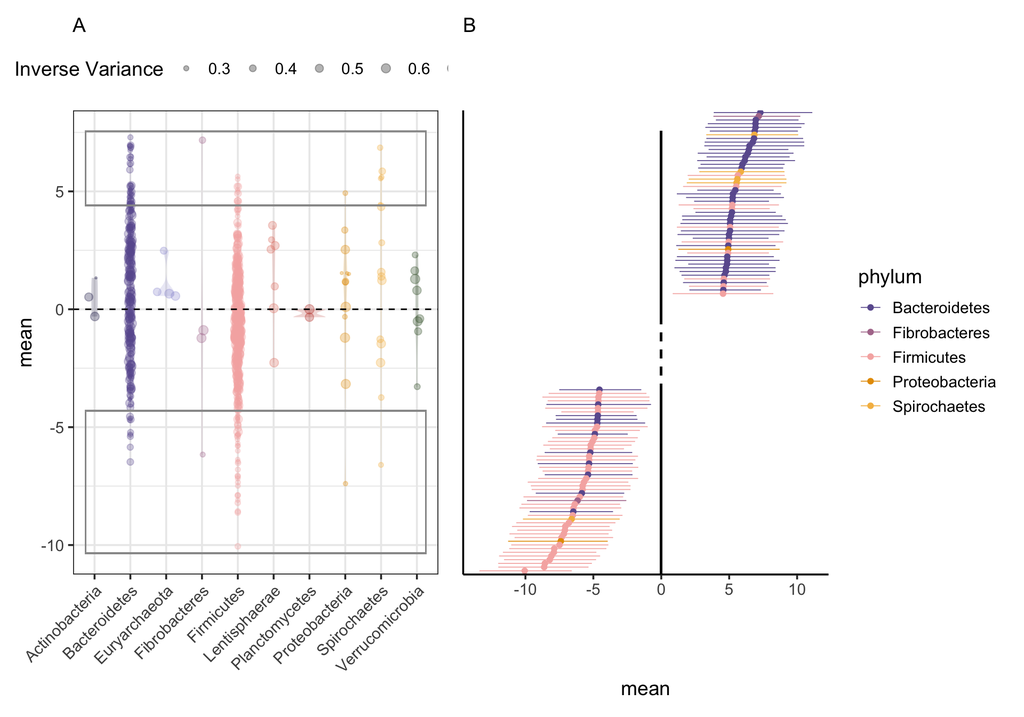

```r
require(patchwork)

AgeSinaRect + AgeTopBottom
```

# 4. Model Extension Examples

## 4A. Gaussian GLMMs

### CLR data prep

#### Put data in correct (matrix format)

```r
df_t <- df  %>%
  dplyr::select(asv:abundance) %>%
  spread(sample, abundance) # spread data to wide format

df_m <-df_t %>%
  column_to_rownames("asv") %>%
  as.matrix() # turn into a matrix
```

#### Calculate CLR values and associated error

The below will create a transformed dataframe, or can read in the CLR format data in the next code chunk

```r
n_sample<-length(unique(df$sample)) #30
x<-aldex.clr(df_m,as.character(seq(1,n_sample)), mc.samples=128, denom="all", verbose=F) # run ALDEx2

y<-melt(getMonteCarloInstances (x)) # extract the data
colnames(y)<-c("asv","mcmc_instance","clr","sample") # tidy for df

z<-aggregate(y$clr,by=list(y$asv,y$sample),FUN=mean) # take mean across monte-carlo samples
meas_var<-aggregate(y$clr,by=list(y$asv,y$sample),FUN=var) # calculate variance across monte-carlo samples
z$sd<-meas_var$x # add variances to data frame
colnames(z)<-c("asv","sample","clr","meas_var") # correct dimensions
mean(z$clr) #  will be very close to zero

meta<- df %>%
  dplyr::select(sample, asv, phylum, abundance, id, age_class, sex)

CLR <- merge(z, meta, by=c("asv", "sample"), all.x=TRUE) #looks good
```

```r
CLR <- read_csv("Data/GLMMMTutorialDatasetCLR.csv")
```

#### Visualising CLR: What’s going on in the above code

Each ASV per sample ends up with a CLR value taking into account the abundance of all other ASVs in the sample and a distribution of possible values, from which error around the CLR estimate is obtained

```r
asvs<- paste0("ASV", seq(1:50)) %>% sample(., size=5)

meanCLR <- z %>% mutate(meanCLR=clr) %>%
  dplyr::select(asv, meanCLR, sample) %>%
  filter(asv %in% asvs) %>%
  mutate(sample_asv=paste(asv, sample, sep="-"))

y_t<-y %>%
  mutate(sample_asv=paste(asv, sample, sep="-")) %>%
  filter(asv %in% asvs)

ridges <- merge(y_t %>% dplyr::select(-c("asv", "sample")), meanCLR, by=c("sample_asv"),
                 all.x=TRUE, all.y=FALSE) %>%
  arrange(meanCLR, mcmc_instance) %>%
  mutate(order=row_number())

require(ggridges)
clr_posteriors <- ridges %>%
  ggplot(aes(x=clr, y=reorder(sample_asv,-meanCLR), group=sample_asv)) +
  scale_x_continuous(limits=c(-15,15))+
  geom_density_ridges(scale=5, size=0.25)+
  theme_minimal() +
  geom_vline(xintercept = 0, linetype="dashed")+
  theme(axis.text.y = element_blank()) + labs(y="asv", x="clr")

clr_posteriors
```

[output not shown]

### CLR model set-up

```r
mf <- 20 # multiplier for model iterations and chains

Prior2 <- list(R = list(V = diag(1), nu = 0.002),
               G = list(G1 = list(V = diag(1), nu = 0.002, alpha.mu = rep(0,1), alpha.V = diag(1)*100),
                        G2 = list(V = diag(1), nu = 0.002, alpha.mu = rep(0,1), alpha.V = diag(1)*100)))
```

```r
Mods[[2]] <-MCMCglmm(clr~ 1,
                  random=~ age_class:asv + asv, # note sample does not need to be included here
                  mev=CLR$meas_var, # measurement error variance
                  data=CLR,
                  prior=Prior2,
                  verbose=T,
                  pr=F, pl=F,
                  nitt= 13000*mf,
                  thin=10*mf, burnin=3000*mf) # start time 1714 finish
```

Notes: * this also takes a fair bit of time (~40 min for me) but will be more efficient for more complex random effect structures * pr & pl are set to F for the purposes of this tutorial, but if you want the posteriors/ predictions saved, set to T

Read in the model object here if you didn’t run the above

```r
Mods[[2]] <- readRDS("Output/GaussianModel.rds")
```

```r
PropVarCLR <- MCMCRep(Mods[[2]]) %>%
  as.data.frame() %>%
  mutate_at(c("Mode", "lHPD", "uHPD"), as.numeric)

PropVarCLR[3,1] <- "mev"
```

## 4B. Hierarchical Taxonomic Effects

- Poisson and CLR models introduced above ask how the asv community varies between age groups, and identify specific asvs which contribute to these differences and may warrant further investigation.
- Differential abundance results in this manuscript (Figure 2) & tutorial (above) indicate that there is a high degree of variation for effects of asvs, even within the same phylum when visualised grouped
- We therefore were further interested in from which taxonomic level most variation arises for observed effects.
- Here we show an alternative to the Poisson model above which considers additional taxonomic levels (ASV, family, phylum) as an example of one approach.
- We note that this nested taxonomic effects approach is not the only way, and that fitting a phylogenetic tree in the random effects structure offers an additional option which explictly accounts for phylogenetic distance.